# Was auf der Wanderung gesagt wurde

## Was auf der Wanderung gesagt wurde

Die Use-Case-Wanderung am AI Retreat, 16. Oktober 2026, ausgewertet mit den sechs Leitfragen

**24**Aufnahmen

**15**Personen

**636**Aussagen zu den Leitfragen

**169**Anwendungsfälle

Jede Aufnahme wurde mit den sechs Leitfragen ausgewertet, jede Aussage einem von 15 Themen zugeordnet. Namen sind entfernt.

Folien online: [larnsce.github.io/ai-retreat-2026](https://larnsce.github.io/ai-retreat-2026/)

Automatisch transkribiert und von einem Sprachmodell codiert, von Lars geprüft. Zählungen zeigen, wie oft etwas angesprochen wurde, keine Gewichtung. Die extrahierten Daten und der Code sind geteilt, alle Zahlen und Grafiken lassen sich reproduzieren: github.com/larnsce/ai-retreat-2026.

## Die meisten Aussagen betreffen Use Cases und Ängste

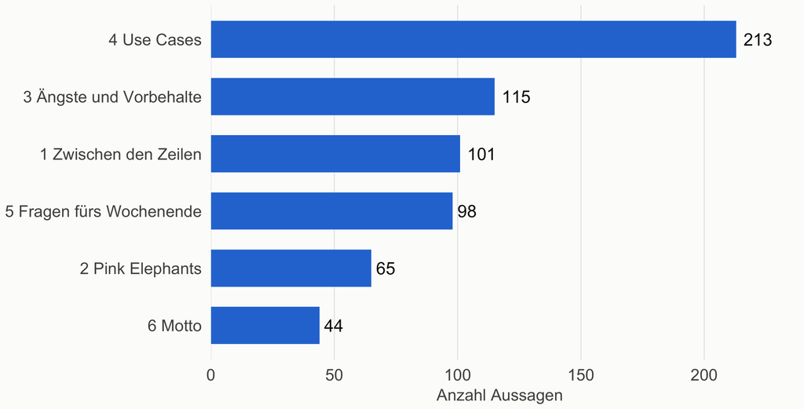

## Was zwischen den Zeilen mitschwingt und worüber niemand spricht

### 1 Zwischen den Zeilen

Eine Person hat das Gefühl, bei der Entwicklung der KI abgehängt zu sein.

«da ist voll viel passiert»

P13, Coaching · Unsicherheit und Selbstzweifel

Viel KI-Nutzung braucht einen Ausgleich durch Sport, was auf eine Belastung durch die Arbeit mit KI hindeutet.

«Je mehr KI’s nutze, desto mehr Sport mache ich.»

P03, Beratung · Belastung und Ausgleich

Eine Person trägt das KI-Thema im Unternehmen fast allein, weil es vorher niemanden dafür gab.

«als hätte es da schon Leute gegeben, die das können»

P11, Technik · Rahmen in der Organisation

### 2 Pink Elephants

Er automatisiert Rekrutierung und beklagt zugleich, dass KI jungen Absolventen den Einstieg versperrt, ohne den eigenen Anteil anzusprechen.

«die nicht mehr in den Job kommen»

P14, Personal · Arbeitsplätze und Ersetzbarkeit

Wer die Verantwortung trägt, wenn sensible Daten in den Graubereich geraten, fragt niemand nach.

P02, Personal · Datenschutz und sensible Daten

Der eigenen Firma fehlt eine KI-Strategie, obwohl sie Kunden beraten soll.

«dieses Wischiwaschi aktuell von allen Ecken»

P07, Projektmanagement · Rahmen in der Organisation

Je drei Aussagen aus den häufigsten Themen der Leitfrage, nicht als sensibel markiert. Personen als Pseudonym (P01 bis P15) mit ihrem Bereich.

«Was ist wirklich Zeitersparnis?»

Leitfrage 5: Welche Fragen sollten wir uns an diesem Wochenende stellen?

## Use Cases: Schreiben und Gestalten ist Alltag, Organisieren noch Wunsch

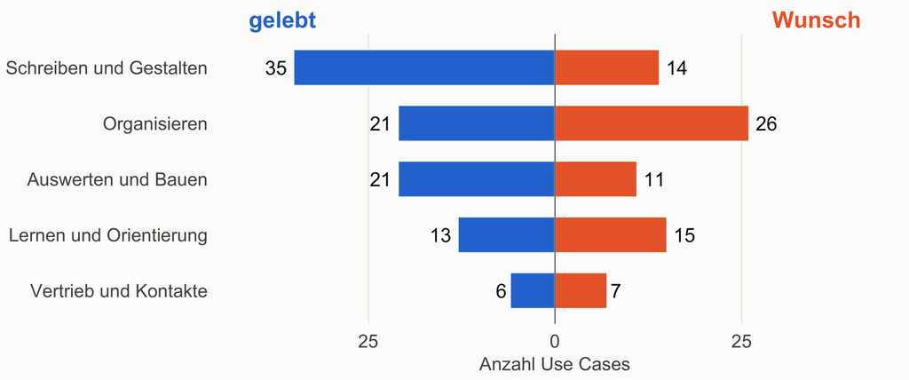

Leitfrage 4: Jeder konkrete Anwendungsfall, den jemand in einem Gespräch nennt, ist eine Zeile (169 insgesamt). «Gelebt» heisst, die Person nutzt ihn schon; «Wunsch» heisst, sie möchte ihn. Gruppiert nach Art der Aufgabe.

## Claude und ChatGPT sind am weitesten verbreitet

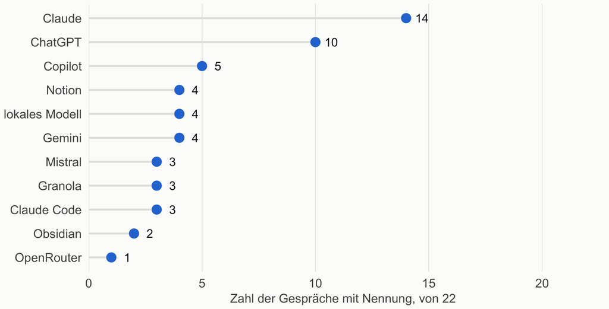

Gezählt per Textsuche in den Transkripten, Hörfehler wie «Clot» für Claude eingeschlossen. Zweitaufnahmen desselben Gesprächs zählen einmal.

«Also der Prozess wird aufgeblasen statt effizienter in der gleichen Zeit.»

Leitfrage 3: Welche Ängste und Vorbehalte gegenüber KI zeigen sich, offen oder versteckt?

## Datenschutz wird ausgesprochen, Unsicherheit bleibt versteckt

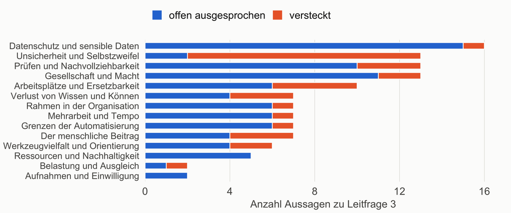

**Offen:** Die Person nennt die Sorge selbst, zum Beispiel «immer so ein bisschen Angst um die Daten». **Versteckt:** Die Sorge wird nicht benannt, sie zeigt sich in Selbstzweifeln, Witzen oder Ausweichen, zum Beispiel «da bin ich noch zu doof». Diese Einordnung hat das Sprachmodell aus dem Gesprächsverlauf vorgenommen; sie ist eine Deutung.

## Fast jeder dritte Use Case berührt Daten über Personen

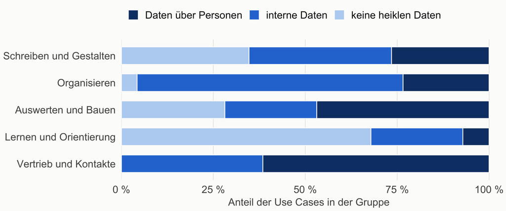

29 % aller Use Cases arbeiten mit Daten über Personen (Mitarbeitende, Kund:innen, Bewerbende, Patient:innen, eigene Gesundheit). Eingeordnet aus der Beschreibung des Use Case.

## 153 Aussagen sind sensibel, vor allem zu Arbeitsplätzen und Datenschutz

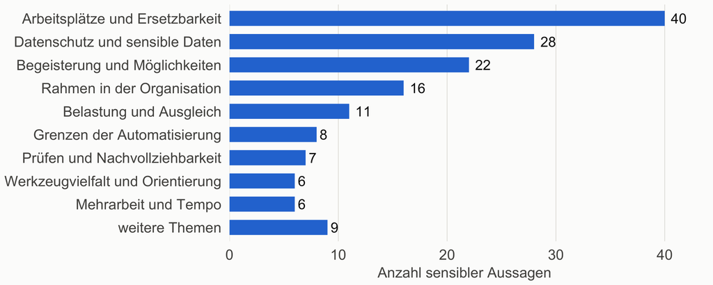

153 von 636 Aussagen (24 %) sind als sensibel markiert, aus 22 Aufnahmen und von 15 Personen. Sensibel heisst: Gesundheit, Stellenabbau oder die eigene Jobsituation, Familie, Finanzen, Firmeninterna oder Daten Dritter. Die meisten stehen bei Leitfrage 4, 2, 1. Ihre Inhalte werden in diesen Folien nicht gezeigt.

«Mehr Zeit fürs Menschliche.»

Leitfrage 6: Wenn diese Gruppe ein Motto für das Wochenende hätte, wie würde es lauten? Darunter die Themen aller Motto-Vorschläge.

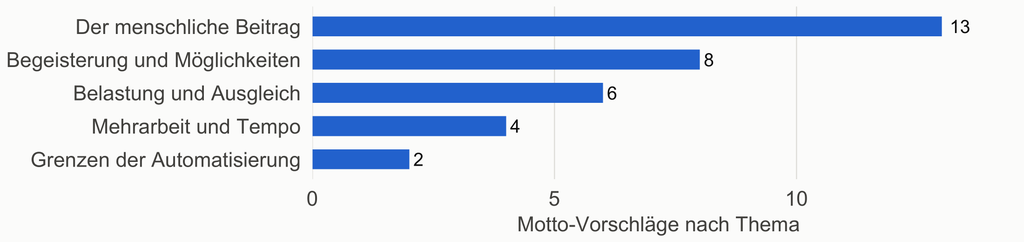